# Sierra manual

[figure not shown]

## Utilidad y partes

La sierra manual es una herramienta para cortar metales, plásticos o madera, dependiendo del tipo de hoja.

Como se observa en la figura, sus partes principales son:

- Arco
- Tornillo tensor
- Hoja

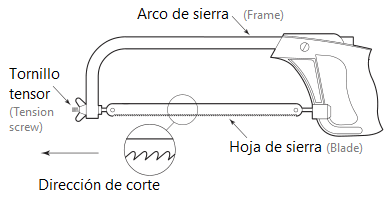

Partes de una sierra - Fuente: Timings (2008)

En la figura también se observa la dirección hacia donde apuntan los dientes cuando se la coloca en el arco.

**Versión en inglés**

The hacksaw is a tool used for cutting metal, plastic, or wood, depending on the type of blade.

As shown in the figure, its main parts are:

- Frame
- Tension screw
- Blade

The figure also shows the direction in which the teeth should point when mounted on the frame.

## Selección de la hoja

En la selección de una hoja de sierra manual el factor más determinante es la cantidad y tamaño de los dientes. Esto se mide en “cantidad de dientes por pulgada”, también llamado TPI (Teeth Per Inch = dientes por pulgada).

**Relación material - cantidad de dientes por pulgada (TPI):**

- **Materiales blandos (aluminio, cobre, plásticos):** hojas de **18 TPI** (dientes grandes, corte rápido).
- **Acero medio y bronce:** hojas de **24 TPI** (equilibrio entre rapidez y prolijidad).
- **Acero duro o piezas delgadas:** hojas de **32 TPI** (dientes pequeños, corte fino y preciso).

> Regla práctica: a mayor dureza del material y menor espesor, mayor cantidad de dientes por pulgada.

En cuanto al material de la hoja, estos normalmente son de “acero rápido” que es suficientemente duro para cortar una gran variedad de materiales.

## Tips de uso

Para usarla correctamente y con seguridad hay que:

- Marcar la línea de corte con punta de marcar.
- Sujetar la pieza en la morsa.
- Ejercer presión solo al avanzar.

También debes agarrarla con ambas manos como se muestra abajo aplicando mayor presión cuando la mueves hacia adelante. En el retroceso casi no se aplica presión.

[figure not shown]

Agarralá con ambas manos, pon más presión uando la mueves hacia adelante

La hoja se coloca normalmente como se muestra en la parte **A** de la figura de abajo. Pero puede girarse como muestra la parte **B** cuando hay que cortar una longitud grande.

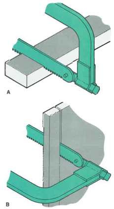

Fuente: Walker (2000)

## Cambio de la hoja

Cuando la hoja presenta dientes desgastados o barridos, es necesario reemplazarla. Los pasos recomendados son:

1. **Aflojar el tornillo tensor** para liberar la tensión de la hoja.
2. **Retirar la hoja usada** quitando los pines o sujetadores que la mantienen en el arco.
3. **Seleccionar una hoja adecuada** para el material a cortar:
   - Si deseas colocar una similar a la anterior, verifica si aún conserva grabada la cantidad de dientes por pulgada (TPI).
   - Si no es legible, cuenta los dientes manualmente para colocar una igual.
   - También puedes consultar la sección *“Selección de la hoja”* para elegir la más conveniente. En caso de duda, una hoja de **24 TPI** suele ser adecuada para diversos trabajos con metal.
4. **Colocar la hoja correctamente**, con los dientes apuntando hacia adelante (dirección de corte).
5. **Ajustar el tornillo tensor** hasta que la hoja quede bien tensa, pero sin excederse para evitar dañar la rosca de la tuerca o del tornillo.

**Algunas fuentes usadas**

- Timings, R. (2008). Fabrication and Welding Engineering. Elsevier.
- Walker, J.R. (2000). Machining Fundamentals. Goodheart-Willcox Company.
- Bahco. Catálogo e información sobre limas.